# HW 3 Solutions

# Chapter 5 (Pg. 101)

## Exercise 1

Here are two heatmaps to build intuition about the problem. The first is the same heatmap as presented on page 101:

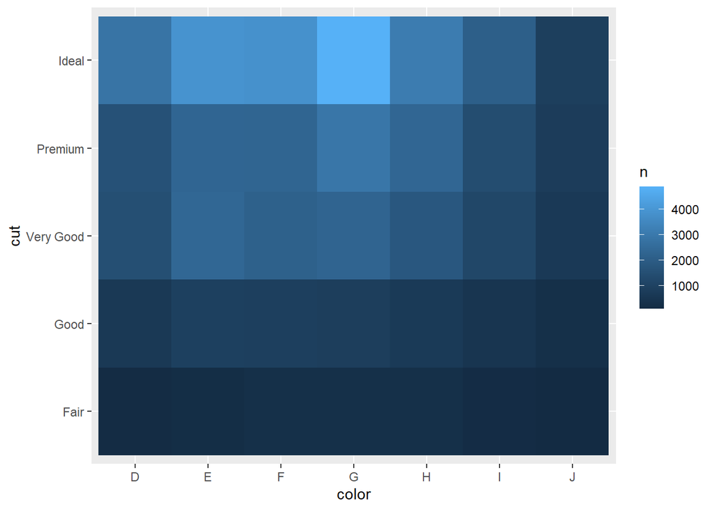

```r
diamonds %>% count(color, cut) %>%
    ggplot(mapping=aes(x=color, y=cut)) + geom_tile(mapping=aes(fill=n))
```

Notice that for Fair diamonds, all the tiles are the same dark blue color–we can’t see any variation. Here’s a similar heatmap, but just of the Fair diamonds:

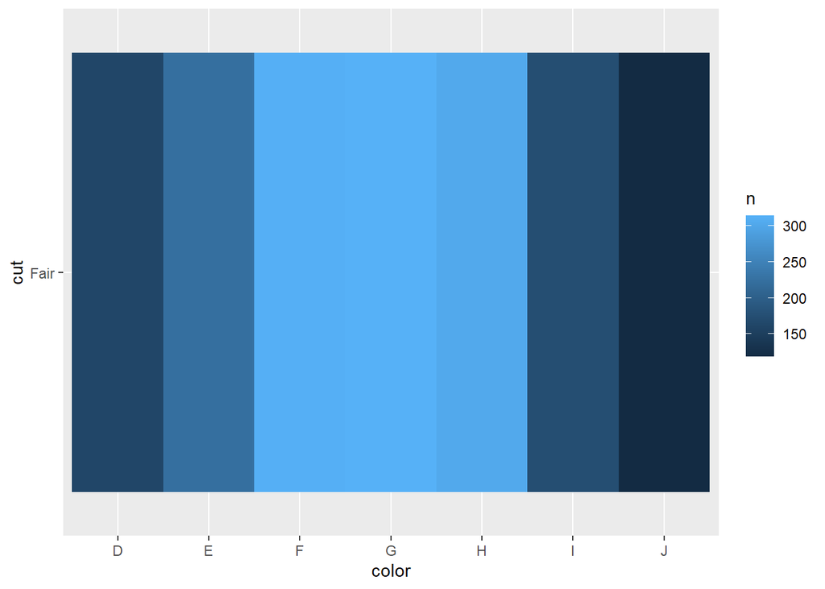

```r
diamonds %>% filter(cut=="Fair") %>%
    count(color, cut) %>%
    ggplot(mapping=aes(x=color, y=cut)) + geom_tile(mapping=aes(fill=n))
```

We can see from the bottom heatmap that G is the most represented color among Fair diamonds, and J is the least represented color. However, we can’t see this information from the top heatmap; in the row for Fair diamonds all the tiles have the same very dark blue color. That’s because the better cuts of diamond (Ideal, Premium, etc.) have much higher counts and are hogging the rest of the color spectrum.

There are two main ways of dealing with this problem: standardizing and log-transforming. Both are acceptable. First we will discuss standardizing.

Standardizing is when we put all of the diamond cuts on the same scale, so that the Ideal diamonds don’t hog all the bright colors. We do this using percentages. Instead of getting the count of each (color, cut) pairing, we will take each cut, and find what percent of diamonds with that cut are each color. Then we’ll make a heatmap based on that:

```r
percentages = diamonds %>%
    count(color, cut) %>%
    group_by(cut) %>%
    mutate(cut_count=sum(n), percentage = 100*n/cut_count) %>%
    arrange(cut)

percentages
```

```
## # A tibble: 35 x 5
## # Groups:   cut [5]
##    color cut       n cut_count percentage
##    <ord> <ord> <int>     <int>      <dbl>
##  1 D     Fair    163      1610      10.1
##  2 E     Fair    224      1610      13.9
##  3 F     Fair    312      1610      19.4
##  4 G     Fair    314      1610      19.5
##  5 H     Fair    303      1610      18.8
##  6 I     Fair    175      1610      10.9
##  7 J     Fair    119      1610       7.39
##  8 D     Good    662      4906      13.5
##  9 E     Good    933      4906      19.0
## 10 F     Good    909      4906      18.5
## # ... with 25 more rows
```

From the first line of this table, we can see that there are 1610 Fair diamonds in the dataset, and 163 of them are color D, so about 10% of the Fair diamonds are color D.

And now we make the heatmap:

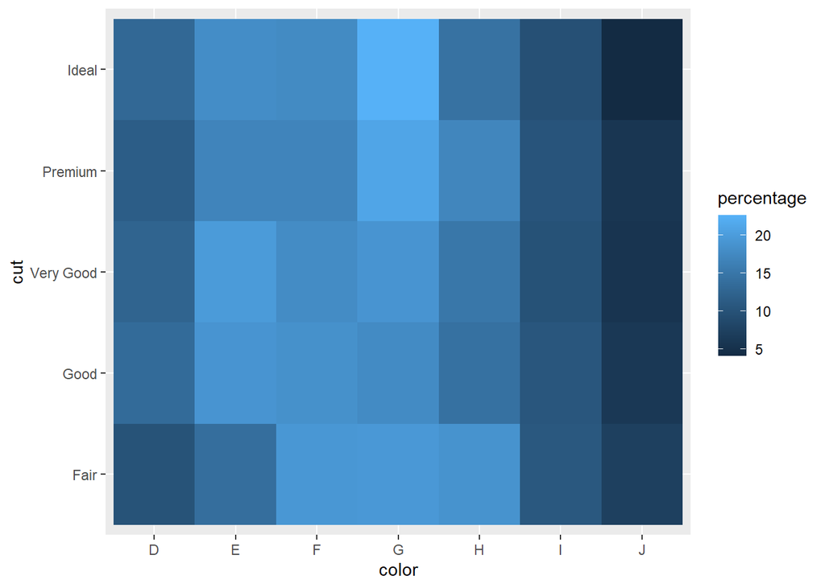

```r
ggplot(percentages, aes(x=color, y=cut)) + geom_tile(aes(fill=percentage))
```

Now it is easy to see visually how color is represented within each cut. We could do a very similar process to see how cut is represented within each color.

The other method of dealing with the problem of scale is log-transforming. Essentially, instead of getting the count of each (cut, color) pair, we get the *order of magnitude* instead. Taking the base-10 log of a number basically tells you how many digits are in it. For example $\log_{10} (1000) = 3$ and $\log_{10} (10000) = 4$. So, a log value of 3.5 tells you that the number was “in the thousands”.

It is easy to make the log-transformed heatmap:

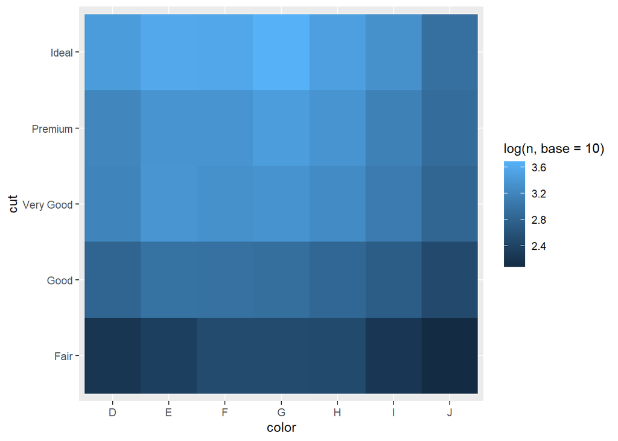

```r
diamonds %>%
    count(color, cut) %>%
    ggplot(aes(x=color, y=cut)) + geom_tile(aes(fill=log(n, base=10)))
```

As we can see, the color scale is distributed nicely among the cuts and colors. We can also see some information about how cuts are distributed with colors and vice-versa, for example, there are more Ideal G diamonds than Ideal J diamonds. However, since the values are on a log scale, we have to be careful when determining how *many* more.

## Exercise 2

First we compute the average delay for each (month, dest) pair:

```r
delays = flights %>% group_by(month, dest) %>% summarize(avg_delay=mean(dep_delay, na.rm=T), count=n())
```

And now we make a heatmap:

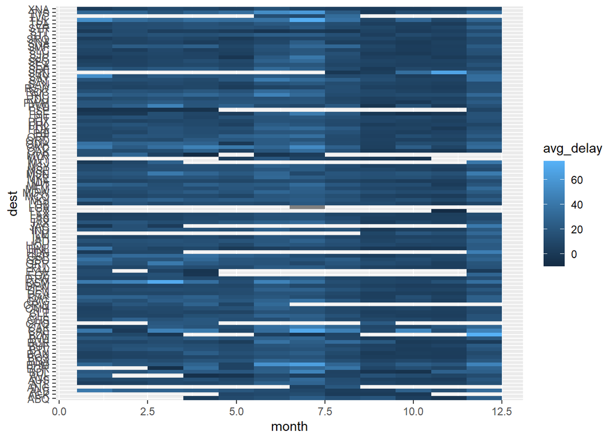

```r
ggplot(delays, aes(x=month, y=dest)) + geom_tile(aes(fill=avg_delay))
```

“Improving” this plot is a broad question that comes down to what you want to explore. The amount of destinations certainly makes this plot harder to read, but seeing all the destinations might be important for the plot. Potential ways to improve the plot could be:

- Group destinations by state or geographic area to cut down the number of rows in the heatmap
- Choose a more neutral color for missing values
- Choose a color scale with more contrast
- If we wanted to see within-group variation like the previous question, we could standardize or log-transform.

# Chapter 5 (Pg. 104)

## Exercise 2

We need make a partition of price; I will use a bin width of $1000.

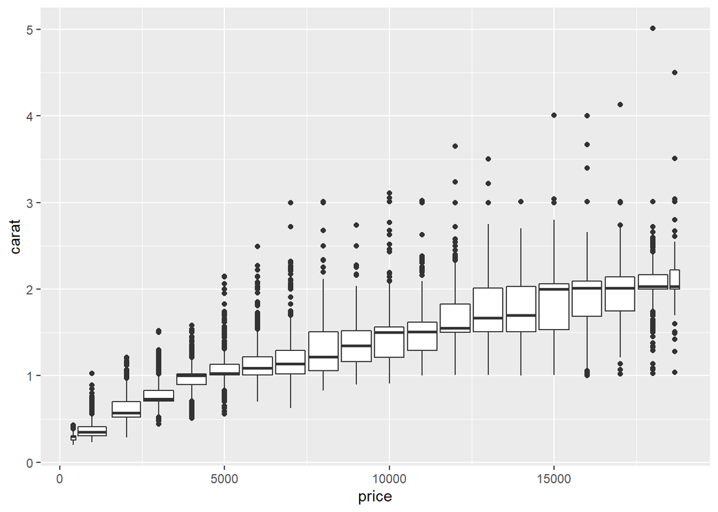

```r
ggplot(diamonds) + geom_boxplot(aes(x=price, y=carat, group=cut_width(price, 1000)))
```

Now for a given price bin, we can see the distribution of `carat`.

## Exercise 3

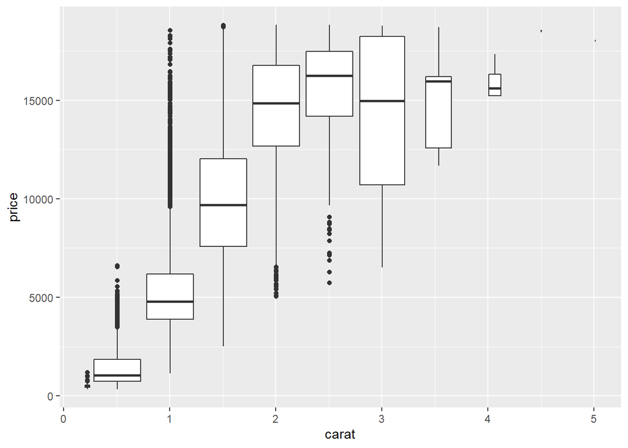

```r
ggplot(diamonds) + geom_boxplot(aes(x=carat, y=price, group=cut_width(carat, 0.5)))
```

As expected, the very large carat diamonds have higher prices than the small diamonds.

## Exercise 5

There are (at least) two ways to make a binned plot from these two continuous variables. We could bin one variable, like we did in exercise above, or we could bin both variables and make a heatmap. First, the given plot:

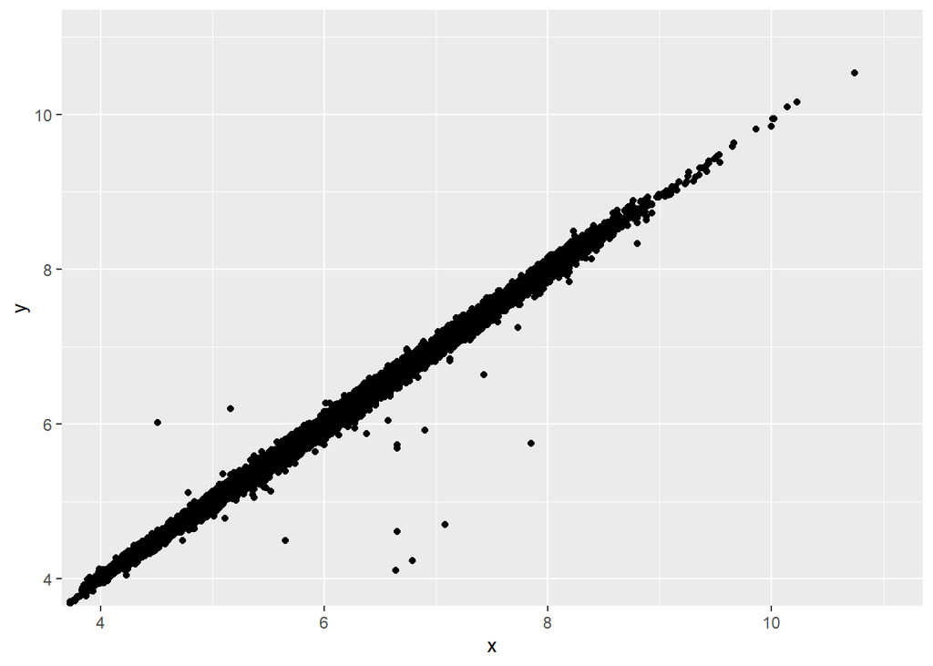

```r
ggplot(diamonds) + geom_point(aes(x=x, y=y)) + coord_cartesian(xlim=c(4,11), ylim=c(4,11))
```

And here’s a binned plot, where I bin each x-value into 1mm groups:

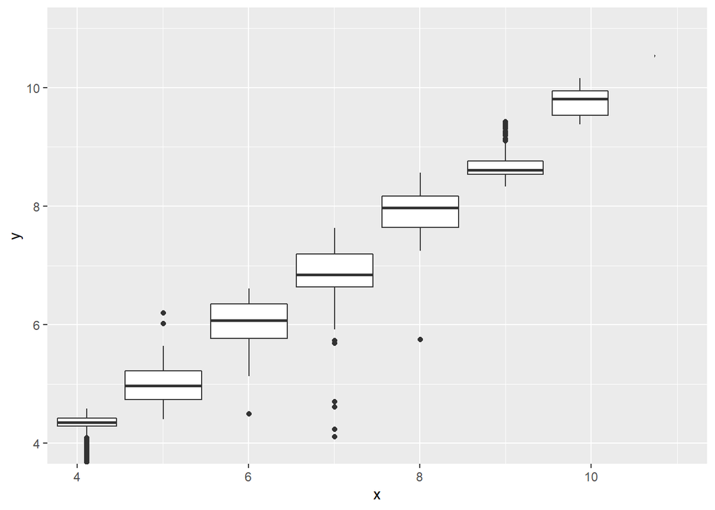

```r
ggplot(diamonds) + geom_boxplot(aes(x=x, y=y, group=cut_width(x, 1))) + coord_cartesian(xlim=c(4,11), ylim=c(4,11))
```

We can still see some of the outliers on the boxplot, but in this case, a scatter plot lets the viewer determine what an outlier should be, rather than the boxplot algorithm.

Finally, here’s a heatmap, where I bin by rounding to the nearest whole millimeter:

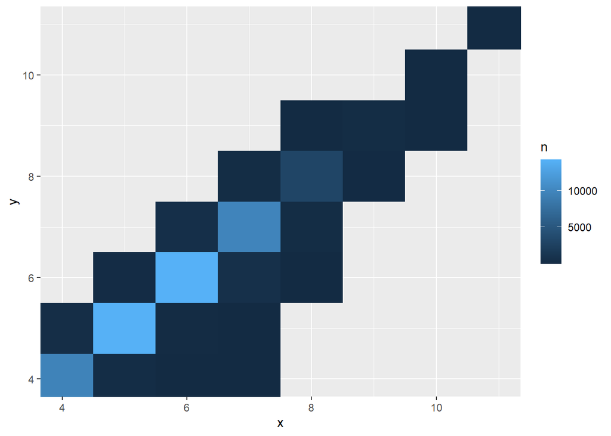

```r
diamonds %>%
    mutate(x=round(x), y=round(y)) %>%
    count(x, y) %>%
    ggplot(aes(x=x, y=y)) + geom_tile(aes(fill=n)) + coord_cartesian(xlim=c(4,11), ylim=c(4,11))
```

This plot is OK, because it shows the general linear relationship between x and y, and it also shows a little information about the outliers, and it shows that as both x and y increase, there are fewer diamonds represented. However, these relationships are all easier to see on the scatterplot, so the binning operation removes information while making harder to read graph. So the scatterplot is better in this case.